# Capitulo 2: Estadistica Descriptiva

Dereck Amesquita

6/4/2021

## ¿Que es la estadistica descriptiva?

Es la rama de la estadistica que nos permite resumir un gran conjunto de datos. “Deducir” un elemento segun un gran conjunto de elementos similares. Con summary podremos obtener los principales datos descritivos de un dataframe

# Datos Cualitativos

```r
prueba=iris
summary(prueba)
```

```
##   Sepal.Length    Sepal.Width     Petal.Length    Petal.Width
##  Min.   :4.300   Min.   :2.000   Min.   :1.000   Min.   :0.100
##  1st Qu.:5.100   1st Qu.:2.800   1st Qu.:1.600   1st Qu.:0.300
##  Median :5.800   Median :3.000   Median :4.350   Median :1.300
##  Mean   :5.843   Mean   :3.057   Mean   :3.758   Mean   :1.199
##  3rd Qu.:6.400   3rd Qu.:3.300   3rd Qu.:5.100   3rd Qu.:1.800
##  Max.   :7.900   Max.   :4.400   Max.   :6.900   Max.   :2.500
##        Species
##  setosa    :50
##  versicolor:50
##  virginica :50
##
##
##
```

## Frecuencias

### Frecuencia absoluta

Es el numero de datos que hay.

### Frecuencia relativa

Es el porcentaje de datos que hay ### Codigo en R Con sample obtener 12 elementos del 40 al 55 donde los elementos se pueden repetir. En Y estamos generando 12 elementos si y no, los cuales estan meditos en un vector y se terminaran convirtiendo en un factor, debido a eso nos arroja que hay dos niveles. La funcion table nos ayuda a contar los elementos que existen.

```r
x = sample(40:55, size = 12, replace=TRUE)
y = factor(sample(c("si", "no"), size=12, replace = TRUE))
x
```

```
##  [1] 46 53 49 49 53 40 54 45 48 49 42 45
```

```r
y
```

```
##  [1] no si si no si si si no no no no no
## Levels: no si
```

Tambien podemos usar la funcion names que nos dara los niveles.

```r
table(x)
```

```
## x
## 40 42 45 46 48 49 53 54
##  1  1  2  1  1  3  2  1
```

```r
table(y)
```

```
## y
## no si
##  7  5
```

```r
names(table(x))
```

```
## [1] "40" "42" "45" "46" "48" "49" "53" "54"
```

Table tiene una desventaje puesto que solo aparecen los valores mayores a cero. Si nuestro datos tienen un nivel el cual no tiene ningun elemento, no se nos sera mostrado. Por lo cual podemos convertirlos a factores. Creamos nx que recogera a x como factores con niveles del 40:55

```r
nx=factor(x, levels=40:55)
table(nx)
```

```
## nx
## 40 41 42 43 44 45 46 47 48 49 50 51 52 53 54 55
##  1  0  1  0  0  2  1  0  1  3  0  0  0  2  1  0
```

Si quisieramos encontrar un valor dentro de la tabla podemos indicarle la posicion o podemos hacer que busque. Solo bastara con usar:

```r
 table(nx)["54"]
```

```
## 54
##  1
```

Para conocer la frecuencia relativa deberemos usar prop.table. Nos da el porcenteja

```r
prop.table(table(nx))
```

```
## nx
##         40         41         42         43         44         45         46
## 0.08333333 0.00000000 0.08333333 0.00000000 0.00000000 0.16666667 0.08333333
##         47         48         49         50         51         52         53
## 0.00000000 0.08333333 0.25000000 0.00000000 0.00000000 0.00000000 0.16666667
##         54         55
## 0.08333333 0.00000000
```

```r
prop.table(table(y))
```

```
## y
##        no        si
## 0.5833333 0.4166667
```

```r
#Si queremos obtener el porcentaje, debemos multiplicar por 100
prop.table(table(y))*100
```

```
## y
##       no       si
## 58.33333 41.66667
```

```r
#Tambien podemos obtener la frecuencia relativa con la division
table(y)/length(y)
```

```
## y
##        no        si
## 0.5833333 0.4166667
```

```r
table(x)==2
```

```
## x
##    40    42    45    46    48    49    53    54
## FALSE FALSE  TRUE FALSE FALSE FALSE  TRUE FALSE
```

## Frecuencias Bidimensionales

Construiremos un nuevo conjunto de datos. LO que haremos sera cruzar la informacion de Y. Con table haremos que cada “se” pueda vincularse con el valor en el orden correspondiente a “y”

```r
se=sample(c("H","M"), replace = TRUE, size=length(y))
table(se,y)
```

```
##    y
## se  no si
##   H  1  5
##   M  6  0
```

### Frecuencia relativa global

```r
prop.table(table(se,y))
```

```
##    y
## se          no         si
##   H 0.08333333 0.41666667
##   M 0.50000000 0.00000000
```

### Frecuencia relativa marginal

Con margin=1 obtenemos la FRM de las filas y con =2 obtenemo la FRM de las columnas

```r
prop.table(table(se,y), margin=1)
```

```
##    y
## se         no        si
##   H 0.1666667 0.8333333
##   M 1.0000000 0.0000000
```

```r
prop.table(table(se,y), margin=2)
```

```
##    y
## se         no        si
##   H 0.1428571 1.0000000
##   M 0.8571429 0.0000000
```

##Crostable

Pertenece al paquete gmodels. Crosstable nos permitira generar de forma automatica las distintas frecuencias.

```r
library(gmodels)
CrossTable(se,y,prop.chisq = FALSE)
```

```
##
##
##    Cell Contents
## |-------------------------|
## |                       N |
## |           N / Row Total |
## |           N / Col Total |
## |         N / Table Total |
## |-------------------------|
##
##
## Total Observations in Table:  12
##
##
##              | y
##           se |        no |        si | Row Total |
## -------------|-----------|-----------|-----------|
##            H |         1 |         5 |         6 |
##              |     0.167 |     0.833 |     0.500 |
##              |     0.143 |     1.000 |           |
##              |     0.083 |     0.417 |           |
## -------------|-----------|-----------|-----------|
##            M |         6 |         0 |         6 |
##              |     1.000 |     0.000 |     0.500 |
##              |     0.857 |     0.000 |           |
##              |     0.500 |     0.000 |           |
## -------------|-----------|-----------|-----------|
## Column Total |         7 |         5 |        12 |
##              |     0.583 |     0.417 |           |
## -------------|-----------|-----------|-----------|
##
##
```

```r
fix(se)
y
```

```
##  [1] no si si no si si si no no no no no
## Levels: no si
```

```r
rev(y)
```

```
##  [1] no no no no no si si si no si si no
## Levels: no si
```

## Datos multidimensionales

```r
#creamos los vectores
per= sample(c("S","N"), size=100, replace = TRUE)
sex= sample(c("H","M"), size=100, replace = TRUE)
lug= sample(c("Peru","Chile","Argentina","Uruguay","Brasil"), size=100, replace = TRUE)
#tablas
table(sex,per,lug)
```

```
## , , lug = Argentina
##
##    per
## sex N S
##   H 4 4
##   M 5 3
##
## , , lug = Brasil
##
##    per
## sex N S
##   H 7 4
##   M 8 4
##
## , , lug = Chile
##
##    per
## sex N S
##   H 6 6
##   M 1 4
##
## , , lug = Peru
##
##    per
## sex N S
##   H 2 8
##   M 8 7
##
## , , lug = Uruguay
##
##    per
## sex N S
##   H 2 5
##   M 5 7
```

```r
ftable(sex,per,lug)
```

```
##         lug Argentina Brasil Chile Peru Uruguay
## sex per
## H   N               4      7     6    2       2
##     S               4      4     6    8       5
## M   N               5      8     1    8       5
##     S               3      4     4    7       7
```

```r
ftable(sex,per,lug, col.vars=c("sex","per"))
```

```
##           sex H   M
##           per N S N S
## lug
## Argentina     4 4 5 3
## Brasil        7 4 8 4
## Chile         6 6 1 4
## Peru          2 8 8 7
## Uruguay       2 5 5 7
```

### Filtrado de tablas

```r
table(sex, per, lug)["M","S","Peru"]
```

```
## [1] 7
```

```r
#Esto nos da todas las mujeres que dijeron que si y son de Peru

table(sex, per, lug)["M",,"Peru"]
```

```
## N S
## 8 7
```

```r
#Esto nos da todas las mujeres que son de Peru.

table(sex, per, lug)[,,"Peru"]
```

```
##    per
## sex N S
##   H 2 8
##   M 8 7
```

```r
#Esto nos da todos lo de Peru
```

# Ejemplo 1

La siguiente base de datos ya funciona como una tabla de frecuencias, se denominan datos agregados. Es como si se hubiera utilizado un table(Eye,Hair,Sex)

```r
HairEyeColor
```

```
## , , Sex = Male
##
##        Eye
## Hair    Brown Blue Hazel Green
##   Black    32   11    10     3
##   Brown    53   50    25    15
##   Red      10   10     7     7
##   Blond     3   30     5     8
##
## , , Sex = Female
##
##        Eye
## Hair    Brown Blue Hazel Green
##   Black    36    9     5     2
##   Brown    66   34    29    14
##   Red      16    7     7     7
##   Blond     4   64     5     8
```

```r
dfx=HairEyeColor
sum(dfx)->total
```

El total de individuos son 592.

```r
prop.table(dfx, margin=3)
```

```
## , , Sex = Male
##
##        Eye
## Hair          Brown        Blue       Hazel       Green
##   Black 0.114695341 0.039426523 0.035842294 0.010752688
##   Brown 0.189964158 0.179211470 0.089605735 0.053763441
##   Red   0.035842294 0.035842294 0.025089606 0.025089606
##   Blond 0.010752688 0.107526882 0.017921147 0.028673835
##
## , , Sex = Female
##
##        Eye
## Hair          Brown        Blue       Hazel       Green
##   Black 0.115015974 0.028753994 0.015974441 0.006389776
##   Brown 0.210862620 0.108626198 0.092651757 0.044728435
##   Red   0.051118211 0.022364217 0.022364217 0.022364217
##   Blond 0.012779553 0.204472843 0.015974441 0.025559105
```

El 11.46% de todos los hombres tiene pelo negro y ojos cafes El 18.99% de todos los hombres tiene pelo cafe y ojos cafes.

```r
prop.table(dfx, margin=c(1,2))
```

```
## , , Sex = Male
##
##        Eye
## Hair        Brown      Blue     Hazel     Green
##   Black 0.4705882 0.5500000 0.6666667 0.6000000
##   Brown 0.4453782 0.5952381 0.4629630 0.5172414
##   Red   0.3846154 0.5882353 0.5000000 0.5000000
##   Blond 0.4285714 0.3191489 0.5000000 0.5000000
##
## , , Sex = Female
##
##        Eye
## Hair        Brown      Blue     Hazel     Green
##   Black 0.5294118 0.4500000 0.3333333 0.4000000
##   Brown 0.5546218 0.4047619 0.5370370 0.4827586
##   Red   0.6153846 0.4117647 0.5000000 0.5000000
##   Blond 0.5714286 0.6808511 0.5000000 0.5000000
```

## Cambiar orden

```r
#modificar el orden de datos agregados
dfxn=aperm(dfx, perm=c("Sex", "Hair","Eye"))
#Mostrar tabla de datos agregados
library("kableExtra")
kable(dfxn)
```

| Sex | Hair | Eye | Freq |
| --- | --- | --- | --- |
| Male | Black | Brown | 32 |
| Female | Black | Brown | 36 |
| Male | Brown | Brown | 53 |
| Female | Brown | Brown | 66 |
| Male | Red | Brown | 10 |
| Female | Red | Brown | 16 |
| Male | Blond | Brown | 3 |
| Female | Blond | Brown | 4 |
| Male | Black | Blue | 11 |
| Female | Black | Blue | 9 |
| Male | Brown | Blue | 50 |
| Female | Brown | Blue | 34 |
| Male | Red | Blue | 10 |
| Female | Red | Blue | 7 |
| Male | Blond | Blue | 30 |
| Female | Blond | Blue | 64 |
| Male | Black | Hazel | 10 |
| Female | Black | Hazel | 5 |
| Male | Brown | Hazel | 25 |
| Female | Brown | Hazel | 29 |
| Male | Red | Hazel | 7 |
| Female | Red | Hazel | 7 |
| Male | Blond | Hazel | 5 |
| Female | Blond | Hazel | 5 |
| Male | Black | Green | 3 |
| Female | Black | Green | 2 |
| Male | Brown | Green | 15 |
| Female | Brown | Green | 14 |
| Male | Red | Green | 7 |
| Female | Red | Green | 7 |
| Male | Blond | Green | 8 |
| Female | Blond | Green | 8 |

# Ejemplo 2

## Arreglos importantes en R

```r
data="https://raw.githubusercontent.com/dereckamesquita/Learning-Before-Estadistica/main/datasets/EnergyDrink.csv"
energy=read.csv(data, sep=";",header = TRUE)
#volver una sola columna en factor
energy$estudio=as.factor(energy$estudio)
#Volver toda un data frame en factor
energy[]=lapply(energy,factor)
#Devolver a numero
energy$X=as.numeric(energy$X)
str(energy)
```

```
## 'data.frame':    122 obs. of  4 variables:
##  $ X      : num  1 2 3 4 5 6 7 8 9 10 ...
##  $ estudio: Factor w/ 4 levels "Industriales",..: 2 3 1 2 1 3 2 1 2 2 ...
##  $ bebe   : Factor w/ 2 levels "No","Si": 1 1 2 2 1 1 2 1 1 1 ...
##  $ sexo   : Factor w/ 2 levels "Hombre","Mujer": 2 1 2 1 2 2 1 1 1 1 ...
```

```r
head(energy)
```

```
##   X      estudio bebe   sexo
## 1 1  Informatica   No  Mujer
## 2 2        Mates   No Hombre
## 3 3 Industriales   Si  Mujer
## 4 4  Informatica   Si Hombre
## 5 5 Industriales   No  Mujer
## 6 6        Mates   No  Mujer
```

```r
summary(energy)
```

```
##        X                  estudio   bebe        sexo
##  Min.   :  1.00   Industriales:37   No:97   Hombre:83
##  1st Qu.: 31.25   Informatica :53   Si:25   Mujer :39
##  Median : 61.50   Mates       :16
##  Mean   : 61.50   Telematica  :16
##  3rd Qu.: 91.75
##  Max.   :122.00
```

```r
colnames(energy)[colnames(energy)=="X"] = "indice"
#eliminar la columna indice
energy=energy[,2:4]
summary(energy)
```

```
##          estudio   bebe        sexo
##  Industriales:37   No:97   Hombre:83
##  Informatica :53   Si:25   Mujer :39
##  Mates       :16
##  Telematica  :16
```

Margin igual 2 especifica que se trabaje con las columnas. Con apply aplicaremos la funcion a todas las columnas

```r
apply(energy, MARGIN = 2, FUN = table)
```

```
## $estudio
##
## Industriales  Informatica        Mates   Telematica
##           37           53           16           16
##
## $bebe
##
## No Si
## 97 25
##
## $sexo
##
## Hombre  Mujer
##     83     39
```

```r
#Si solo queremos una columna
apply(energy, MARGIN = 2, FUN = table)$sexo
```

```
##
## Hombre  Mujer
##     83     39
```

```r
#El anterior es igual a
table(energy$sexo)
```

```
##
## Hombre  Mujer
##     83     39
```

```r
table(energy)
```

```
## , , sexo = Hombre
##
##               bebe
## estudio        No Si
##   Industriales 19  6
##   Informatica  30  7
##   Mates         8  1
##   Telematica   10  2
##
## , , sexo = Mujer
##
##               bebe
## estudio        No Si
##   Industriales 10  2
##   Informatica  11  5
##   Mates         6  1
##   Telematica    3  1
```

# Datos Ordinales

Son datos que presentan un orden natural. Por ejemplo las escalas.

```r
notas = ordered(c("S","A", "N", "Ex", "S", "S", "Ex", "Ex", "N", "A", "A", "A",
                  "A", "N", "S"), levels = c("S", "A", "N", "Ex"))
table(notas)
```

```
## notas
##  S  A  N Ex
##  4  5  3  3
```

```r
web = c("cir","cir","winay")
web=data.frame(web)
table(web)
```

```
## web
##   cir winay
##     2     1
```

Nos indica el número de S, A, N y Ex.

Ahora tenemos 50 clientes que calificaron nuestro producto desde el 1 al 5.

```r
clientes = sample(1:5, 50, replace = TRUE)
clientes
```

```
##  [1] 3 4 1 5 3 2 2 1 3 4 5 4 5 4 1 3 5 4 5 2 3 2 2 4 5 2 1 2 3 3 1 4 2 4 3 4 5 3
## [39] 2 2 2 1 3 3 4 4 3 5 5 4
```

```r
FAclientes=table(clientes)
prop.table(FAclientes)
```

```
## clientes
##    1    2    3    4    5
## 0.12 0.22 0.24 0.24 0.18
```

## La funcion Cumsum para Acumuladas

Podemos obtener las frecuencias absolutas **acumuladas** siempre y cuando le demos a cumsum una “table”.

```r
#Para Absolutas
frecuencia_absoluta=table(notas)
cumsum(frecuencia_absoluta)#Obtenemos la acumulada
```

```
##  S  A  N Ex
##  4  9 12 15
```

```r
#Para relativas
frecuencia_relativa=prop.table(frecuencia_absoluta)
cumsum(frecuencia_relativa)
```

```
##         S         A         N        Ex
## 0.2666667 0.6000000 0.8000000 1.0000000
```

### Graficando las frecuencias con cumsum

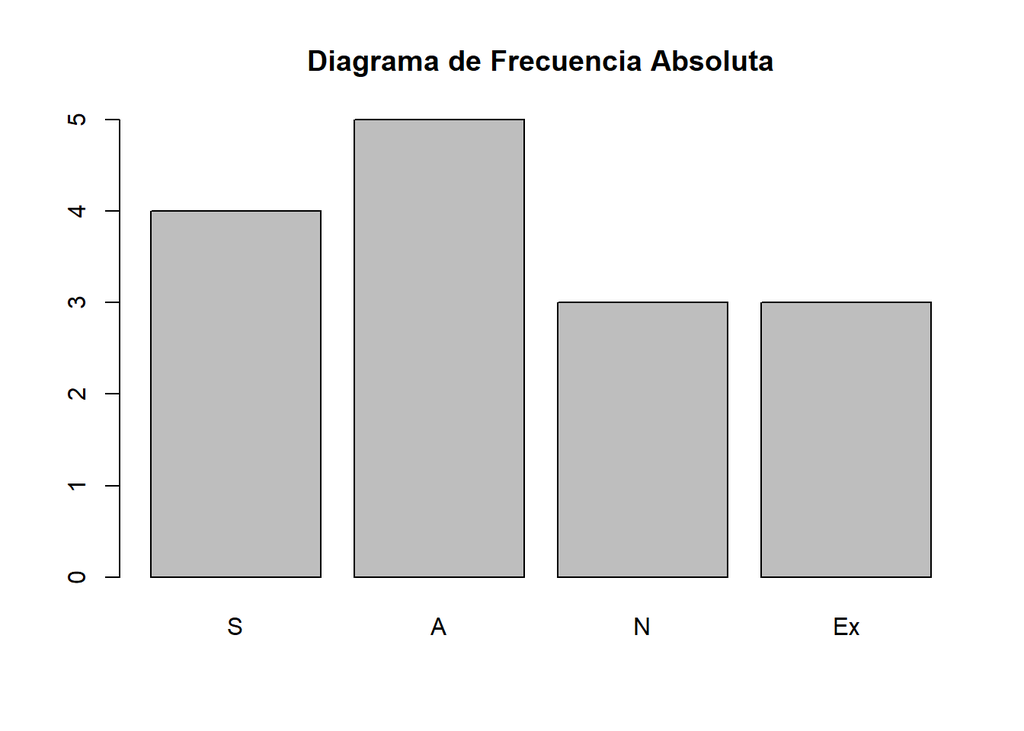

```r
barplot(frecuencia_absoluta, main="Diagrama de Frecuencia Absoluta")
```

### Ejercicio Jirafas

```r
#Esta es otra forma de colocar los niveles y el ordered, en el ejemplo de notas lo pusimos todo junto
longitud = sample(1:5,100, replace = TRUE)
longitud = ordered(longitud)
levels(longitud) = c("Muy.corto","Corto","Normal","Largo","Muy.largo")

#Calculamos sus frecuencias
fre_absoluta=table(longitud)
fre_relativa=prop.table(fre_absoluta)
fre_absoluta
```

```
## longitud
## Muy.corto     Corto    Normal     Largo Muy.largo
##        22        20        21        14        23
```

```r
fre_relativa
```

```
## longitud
## Muy.corto     Corto    Normal     Largo Muy.largo
##      0.22      0.20      0.21      0.14      0.23
```

```r
#Calcumos sus frecuencias acumuladas
fre_absol_acu=cumsum(fre_absoluta)
fre_relat_acu=cumsum(fre_relativa)
fre_absol_acu
```

```
## Muy.corto     Corto    Normal     Largo Muy.largo
##        22        42        63        77       100
```

```r
fre_relat_acu
```

```
## Muy.corto     Corto    Normal     Largo Muy.largo
##      0.22      0.42      0.63      0.77      1.00
```

### Expansion del ejercicio jirafas

Supongamos que en el ejemplo anterior, el de las jirafas, estas provienen de 4 zonas diferentes, A,B,C y D, de manera que las 30 primeras son de la zona A, las 25 siguientes de la B, las 35 siguientes de la C y las 10 últimas de la D. Nos interesa estudiar la distribución de las longitudes según la zona. En este caso en concreto, la sintaxis de la instrucción sería

apply(tabla, MARGIN=…, FUN=cumsum)

donde el valor MARGIN ha de ser el de la dimensión en la que queremos acumular las frecuencias: 1 si queremos hacerlo por filas, 2 para hacerlo por columnas, etc. Lo veremos todo más claro con un ejemplo

```r
zonas=rep(c("A","B","C","D"), c(30,25,35,10))
jirafas=data.frame(zonas,longitud)
jirafas
```

```
##     zonas  longitud
## 1       A    Normal
## 2       A Muy.largo
## 3       A Muy.largo
## 4       A     Corto
## 5       A     Corto
## 6       A     Largo
## 7       A     Largo
## 8       A     Corto
## 9       A    Normal
## 10      A     Corto
## 11      A Muy.corto
## 12      A    Normal
## 13      A     Corto
## 14      A Muy.largo
```

[output cut: 86 more lines]

```r
str(jirafas)
```

```
## 'data.frame':    100 obs. of  2 variables:
##  $ zonas   : chr  "A" "A" "A" "A" ...
##  $ longitud: Ord.factor w/ 5 levels "Muy.corto"<"Corto"<..: 3 5 5 2 2 4 4 2 3 2 ...
```

```r
fila_acumulada=apply(table(jirafas), MARGIN = 1, FUN = cumsum)#porfila
t(fila_acumulada)
```

```
##      longitud
## zonas Muy.corto Corto Normal Largo Muy.largo
##     A         5    12     17    21        30
##     B         5    11     17    19        25
##     C         8    12     20    27        35
##     D         4     7      9    10        10
```

# Datos Cuantitativos

Datos para representar números de cierta medida. Estos son los mas usados. En vez de decir que la jirafa tiene el cuello muy corto o muy largo, podriamos cuantificarla en ese caso podemos tener datos continuos para medir el cuello de la jirafa. Necesitaremos hacer uso de los estadísticos. Podemos usar todo lo que usamos en los otros tipos de datos incluso ahora podemos trabajar por intervalos.

**Continuos** Estos datos tienen presición infinita, todos los datos de una recta, tienen decimales, como por ejemplo el tiempo, las distancias, la altura, el peso. **Discreto** Solo pueden tomar números contables como tal, enteros. Ejemplo el numero de alumnos, numero de cabellos, numero de lanzamiento de una moneda.

## Frecuencia de datos cuantitativos

```r
set.seed(15)
edad=sample(10:40,20, replace = TRUE)
edad
```

```
##  [1] 14 24 19 11 34 15 26 14 24 34 21 20 29 15 10 21 30 14 32 11
```

```r
table(edad)
```

```
## edad
## 10 11 14 15 19 20 21 24 26 29 30 32 34
##  1  2  3  2  1  1  2  2  1  1  1  1  2
```

En general, supongamos que tenemos $n$ observaciones de una propiedad que se mide con un número real y obtenemos la variable cuantitativa formada por los datos
$$x_1,\dots, x_n$$

Sean ahora $X_1,\dots,X_k$ los valores distintos que aparecen en esta lista de datos y considerémoslos ordenados
$$X_1<X_2<\cdots<X_k$$

Entonces, en esta variable cuantitativa

- La frecuencia absoluta de $X_i$ es el número $n_i$ de elementos que son iguales a $X_i$
- La frecuencia relativa de $X_i$ es $f_i=\frac{n_i}{n}$
- La frecuencia absoluta acumulada de $X_i$ es $N_i=\sum_{j=1}^in_j$
- La frecuencia relativa acumulada de $X_i$ es $F_i=\frac{N_i}{n}$

### Ejercicio 3.2

Lanzamos 25 veces un dado de 6 caras y anotamos las puntuaciones obtenidas en cada tirada.

En este caso, $n=25$ y, los distintos valores observados son

$$X_1 = 1,\ X_2 = 2,\ X_3 = 3,\ X_4 = 4,\ X_5 = 5,\ X_6 = 6$$

```r
set.seed(16208) #Obtenemos determinado aleatorio
dados = sample(1:6,25,replace = TRUE)
dados
```

```
##  [1] 2 2 6 6 3 3 3 5 6 3 3 1 2 3 1 5 1 5 4 4 3 5 5 2 2
```

```r
set.seed(NULL) #eliminamos el control de datos
fre_absol_dados=table(dados)
frec_rel_dados=prop.table(fre_absol_dados)
fre_absol_dados
```

```
## dados
## 1 2 3 4 5 6
## 3 5 7 2 5 3
```

```r
round(frec_rel_dados,1) #Pedimos solo un decimal
```

```
## dados
##   1   2   3   4   5   6
## 0.1 0.2 0.3 0.1 0.2 0.1
```

```r
cumsum(fre_absol_dados) #acumulado absoluto
```

```
##  1  2  3  4  5  6
##  3  8 15 17 22 25
```

```r
cumsum(frec_rel_dados) #acumulado relativo
```

```
##    1    2    3    4    5    6
## 0.12 0.32 0.60 0.68 0.88 1.00
```

```r
# Creamos un dataframe para consolidar la informacion
dados.df=data.frame(Numero=1:6,
                    FA=as.vector(fre_absol_dados),
                    FR=as.vector(frec_rel_dados),
                    FAA=as.vector(cumsum(fre_absol_dados)),
                    FRA=as.vector(cumsum(frec_rel_dados)))
str(dados.df)
```

```
## 'data.frame':    6 obs. of  5 variables:
##  $ Numero: int  1 2 3 4 5 6
##  $ FA    : int  3 5 7 2 5 3
##  $ FR    : num  0.12 0.2 0.28 0.08 0.2 0.12
##  $ FAA   : int  3 8 15 17 22 25
##  $ FRA   : num  0.12 0.32 0.6 0.68 0.88 1
```

## Medidas de tendencia central

Las medidas de tendencia central mas importantes se dividen en 3, media, mediana y moda.

### La media

$$\bar{x} = \frac{\sum_{i=1}^nx_i}{n}=\frac{\sum_{j=1}^kn_jX_j}{n}=\sum_{j=1}^kf_jX_j$$
Se expresa como media de x igual a la sumatoria de cada elemento de x desde la posicion 1 hasta la posición n, donde se dividirá respecto a la ultima posición. Esto es igual a la multiplicación de la frecuencia absoluta por el numero de observaciones de esta, dividido entre el total. Pero recordemos:

$$\frac{n_j}{n}=f_j$$
Por tanto podemos llegar que la sumatoria de frecuencias relativas multiplicadas por la frecuencia absoluta. Esto lo podemos entender como la multiplicacion de la frencia absoluta por su probabilidad, lo cual nos conduce a la media. En temas de estadistica inferencia se usa mas esta version.

### La mediana

Presenta el valor central cuando ordenamos las observaciones. Si tenemos la siguiente serie ordenada de menor posicion a mayor:
$$x_{(1)}\le x_{(2)}\le\dots\le x_{(n)}$$

```r
sort(edad) #Ordenamos de menor a mayor, usando FALSE podemos hacerlo decreciente
```

```
##  [1] 10 11 11 14 14 14 15 15 19 20 21 21 24 24 26 29 30 32 34 34
```

```r
edad=sort(edad) #actualizamos el vector
#Podemos calcular la media usando la formula
mediana_edad=(edad[length(edad)/2]+edad[length(edad)/2+1])/2
mediana_edad
```

```
## [1] 20.5
```

```r
media_edad=sum(edad)/length(edad)
media_edad
```

```
## [1] 20.9
```

```r
median(edad)#Esta es la funcion que nos da la mediana
```

```
## [1] 20.5
```

```r
mean(edad) #Esta funcion nos da la media
```

```
## [1] 20.9
```

### La moda

Es el valor que mas veces se repite. Usando as.numeric pediremos que el valor sea considerado como un numero, which buscara que elemento de la tabla de edad es decir de los valores absolutos es igual al maximo de esos valores y nos arrojara la posicion del elemento de la tabla de edad.

```r
as.numeric(names(which(table(edad)==max(table(edad)))))
```

```
## [1] 14
```

```r
#which nos devuelve las posiciones de los valores que cumplen la condicion
z=c(1,2,2,4,2,5)
which(z==2)
```

```
## [1] 2 3 5
```

**Media aritmética**

$$\bar{x} = \frac{1}{n}\sum_{i=1}^n x_i$$

**Media aritmética ponderada**

$$\bar{x}_w = \frac{\sum_{i=1}^nw_i\cdot x_i}{\sum_{i=1}^n w_i}$$
**Media geométrica** Con la funcion prod podemos obtener la producctoria. Este tipo de media nos sirven para calcular el crecimiento.
$$\bar{x}_G = \left(\prod_{i=1}^n x_i\right)^{1/n}$$

**Media armónica**

$$\bar{x}_A = \frac{n}{\sum_{i=1}^{n}\frac{1}{x_i}}$$

```r
x=c(15,14,18,19,24,12,16,13,18,20,16)
n= length(x)
#Media Aritmetica
media_aritmetica=sum(x)/n
round(media_aritmetica,2)
```

```
## [1] 16.82
```

```r
#Media Aritmetica ponderada
w=c(8,5,4,6,4,8,6,1,4,2,3)
media_aritmetica_ponde=sum(x*w)/sum(w)
media_aritmetica_ponde
```

```
## [1] 16.41176
```

```r
#Media Geometrica
media_geometrica=prod(x)^(1/n)
media_geometrica
```

```
## [1] 16.50622
```

```r
#Media Armonica
media_armonica=n/sum(1/x)
media_armonica
```

```
## [1] 16.206
```

## Medidas de posicion

Estas medidas se encargan de determinar que valores dividen las observaciones en determinadas posiciones.

```r
set.seed(15)
dado=sample(1:4, 50, replace = TRUE)
set.seed(NULL)
dado=sort(dado)
dado
```

```
##  [1] 1 1 1 1 1 1 1 1 1 1 1 1 1 1 1 2 2 2 2 2 2 2 2 2 2 2 2 2 2 2 2 3 3 3 3 3 3 3
## [39] 3 3 3 3 3 4 4 4 4 4 4 4
```

```r
#Creamos dataframe
dado.df=data.frame(puntuacion=1:4,
                   Fre.Abs=as.vector(table(dado)),
                   Fre.Rel=as.vector(prop.table(table(dado))),
                   Fre.Abs.Acu=as.vector(cumsum(table(dado))),
                   Fre.Rel.Acu=as.vector(cumsum(prop.table(table(dado)))))
dado.df
```

```
##   puntuacion Fre.Abs Fre.Rel Fre.Abs.Acu Fre.Rel.Acu
## 1          1      15    0.30          15        0.30
## 2          2      16    0.32          31        0.62
## 3          3      12    0.24          43        0.86
## 4          4       7    0.14          50        1.00
```

```r
#Si queremos saber donde cae el percentil 50 podemos calcularlo mediante
dado[0.5*length(dado)]
```

```
## [1] 2
```

```r
#El Percentil 50 cae en la segunda ubicacion. Al mismo tiempo este percentil es la mediana
```

### Los cuantiles

El cuantil de orden 0,36 dejaría un 36% de valores por debajo y el cuantil de orden 0,50 se corresponde con la mediana de la distribución. https://es.wikipedia.org/wiki/Cuantil Los **cuartiles** son la division entre 4 del total. Tenemos $Q_{0.25},Q_{0.5}$ y $Q_{0.75}$.

Los deciles dividen el total entre 10. $Q_p$ donde p es multiple de 0.1

Los percentiles dividen el total entre 100. El percentil 5 es el que considera al 5% de todos los datos. $Q_p$ con $p$ un múltiplo de 0.01. El cuantil se maneja en porcentaje es decir 0.3, en percentil seria 30.

```r
set.seed(20)
dados_a=sample(1:6,50, replace = TRUE)
dados_a
```

```
##  [1] 6 3 2 1 2 5 6 6 5 1 3 5 1 5 6 2 4 1 5 1 1 6 4 6 5 1 5 2 1 6 5 2 3 5 3 1 4 5
## [39] 6 5 5 2 2 6 6 5 3 5 1 1
```

```r
set.seed(NULL)
quantile(dados_a,0.25) # Es similar a manejar percentiles/100
```

```
## 25%
##   2
```

```r
quantile(dados_a,0.80)
```

```
## 80%
## 5.2
```

```r
quantile(dados_a,0.45)
```

```
##  45%
## 3.05
```

```r
sort(dados_a)
```

```
##  [1] 1 1 1 1 1 1 1 1 1 1 1 2 2 2 2 2 2 2 3 3 3 3 3 4 4 4 5 5 5 5 5 5 5 5 5 5 5 5
## [39] 5 5 6 6 6 6 6 6 6 6 6 6
```

Tenemos por debajo del 25% al 2. Es decir 2 deja por debajo al 25% de los datos. Si ordenamos la lista, veremos que al 25% aparecen el 1 y el 2. Debajo del 80% tenemos al 5.2. Es decir hasta el 5.2 se encuentra el 80% de los datos